# TASK (dataset: postterm)

Amanda Wittendorf

2026-10-05

2026-10-01

## 1. DESKRIPTION ON THE DATASET

The dataset contains information on post-term birth for 12311 parturient women. More specifically:

- $\text{ptd}$: Status for post-term birth; if the child was after week 42 is defined as post-term while a child born before or after week 42 is defined as not born post-term (Yes / No)
- $\text{parity}$: The number of which a mother has given birth; primiparous is defined as a first time mother while multiparous is defined as women who have given birth before (primipara / multipara)
- $\text{age}$: Maternal age (year)

## 2. SIMPLE LOGISTIC REGRESSION MODEL

### 2.1 ASSOCIATION BETWEEN STATUS FOR POST-TERM BIRTH ($\text{ptd}$) & MATERNAL AGE $\text{age}$.

**The model**
$$\text{ptd} =
\beta_\text{0} + \beta_\text{1} \cdot \text{age}$$

**Table 1: Association between post-term birth and maternal age**

|  | *Dependent variable:* |
| --- | --- |
|  | Post-term birth (ptd) |
| Maternal age (year) | 1.02*** |
|  | (1.01, 1.03) |
| Intercept | 0.24*** |
|  | (0.18, 0.31) |
| Observations | 12,311 |
| *Note:* | p<0.05; p<0.01; p<0.001 |
|  | Post-term birth (ref. = No) |

```
##
## Table 1: Association between post-term birth (ref. = No) & maternal age
## =================================================
##                          Dependent variable:
##                     -----------------------------
##                         Post-term birth (ptd)
## -------------------------------------------------
## Maternal age (year)            1.02***
##                             (1.01, 1.03)
##
## Intercept                      0.24***
##                             (0.18, 0.31)
##
## -------------------------------------------------
## Observations                   12,311
## =================================================
## Note:               *p<0.05; **p<0.01; ***p<0.001
```

**INTREPETATION**

**Intercept:** The statistically significant odds for having post-term birth ($\text{ptd}$) for mothers who has a maternal age at 0 years ($\text{age}=0$) - this is not of biological meaning because of the maternal age.

**Maternal age (years)** For each year the maternal age increases, the odds for having a post-term birth will increases significant with 1.02 (1.01; 1.03, p< 0.001).

#### 2.1.1 Calculate OR for a specific age difference of 10 years.

To calculate this, the `hypotheses()`-function is used without including the intercept. This is because we are evaluating the relative effect of a 10-year age difference rather than an absolute value. Conversely, if we were to predict the specific odds or probability for an individual case, the intercept would be required.

Table 2: Hypothesis test

| Parameter | OR | Lower limits | Upper limits | p |
| --- | --- | --- | --- | --- |
| Age difference, 10 years | 1.17 | 1.07 | 1.28 | < 0.001 |

**INTERPRETATION**

```
##            Hypothesis test   OR CI_low CI_high       p
## 1 Age difference, 10 years 1.17   1.07    1.28 < 0.001
```

**INTERPRETATION**

The p-value remains the same when comparing the exposure ($\text{age}$) and the predicted value ($\text{age}_{diff(10)}$) because both tests evaluate the same underlying hypothesis: *whether maternal age is associated with post-term birth*

#### 2.1.2 Assessment of the linearity assumption (on the log-odds scale)

> Linearity assumption Proportionality of continuous variables: A one-unit difference in the variable has the same effect, regardless of the baseline value of the variable.

To assess the linearity we need to divide the continuous variable age into appropriate categories and then manually calculate the odds of a preterm birth within each of these groups.

To do so, the function `summarise()` is used to calculate the total number of births as well as the number of post-term births for each age group. In addition, risk (p), odds, and log-odds (logodds) with the corresponding standard error and the lower and upper limits of a 95% confidence interval are calculate.

Table: Assessment of the linearity assumption

| Parameter | Total births (N) | Post-term births (n) | Risk (p) | Odds | Log-odds | Standard error (SE) | Upper limits | Lower limits |
| --- | --- | --- | --- | --- | --- | --- | --- | --- |
| 20 | 262 | 63 | 0.24 | 0.32 | -1.15 | 0.14 | -0.87 | -1.43 |
| 21 | 284 | 67 | 0.24 | 0.31 | -1.18 | 0.14 | -0.90 | -1.45 |
| 22 | 384 | 91 | 0.24 | 0.31 | -1.17 | 0.12 | -0.93 | -1.40 |
| 23 | 492 | 133 | 0.27 | 0.37 | -0.99 | 0.10 | -0.79 | -1.19 |
| 24 | 612 | 168 | 0.27 | 0.38 | -0.97 | 0.09 | -0.79 | -1.15 |
| 25 | 738 | 179 | 0.24 | 0.32 | -1.14 | 0.09 | -0.97 | -1.31 |
| 26 | 889 | 234 | 0.26 | 0.36 | -1.03 | 0.08 | -0.88 | -1.18 |
| 27 | 1108 | 304 | 0.27 | 0.38 | -0.97 | 0.07 | -0.84 | -1.10 |
| 28 | 1117 | 319 | 0.29 | 0.40 | -0.92 | 0.07 | -0.79 | -1.05 |
| 29 | 1103 | 309 | 0.28 | 0.39 | -0.94 | 0.07 | -0.81 | -1.08 |
| 30 | 1043 | 282 | 0.27 | 0.37 | -0.99 | 0.07 | -0.86 | -1.13 |
| 31 | 922 | 258 | 0.28 | 0.39 | -0.95 | 0.07 | -0.80 | -1.09 |
| 32 | 771 | 244 | 0.32 | 0.46 | -0.77 | 0.08 | -0.62 | -0.92 |
| 33 | 676 | 179 | 0.26 | 0.36 | -1.02 | 0.09 | -0.85 | -1.19 |
| 34 | 519 | 169 | 0.33 | 0.48 | -0.73 | 0.09 | -0.54 | -0.91 |
| 35 | 451 | 127 | 0.28 | 0.39 | -0.94 | 0.10 | -0.73 | -1.14 |
| 36 | 343 | 105 | 0.31 | 0.44 | -0.82 | 0.12 | -0.59 | -1.05 |
| 37 | 266 | 74 | 0.28 | 0.39 | -0.95 | 0.14 | -0.69 | -1.22 |
| 38 | 191 | 57 | 0.30 | 0.43 | -0.85 | 0.16 | -0.54 | -1.16 |
| 39 | 140 | 37 | 0.26 | 0.36 | -1.02 | 0.19 | -0.65 | -1.40 |

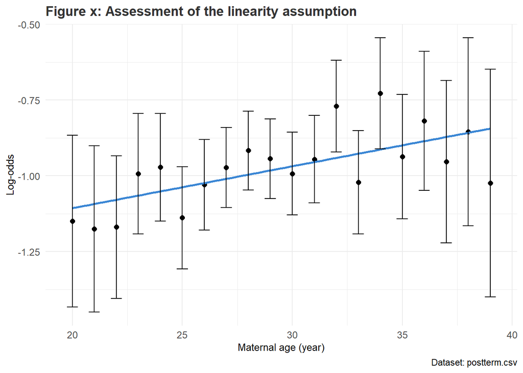

**INTERPRETATION**

**In conclusion, a one-unit difference in the maternal age has the same effect regardless of the baseline value of the variable.**

## 3. MULTIPLE LOGISTIC REGRESSION MODEL

### 3.1. ASSOCIATION BETWEEN STATUS FOR POST-TERM BIRTH ($\text{ptd}$) & MATERNAL AGE $\text{age}$ ADJUSTED FOR PARITY ($\text{parity}$)

**The model**
$$\text{ptd} =
\beta_\text{0} + \beta_\text{1} \cdot \text{age} + \beta_\text{2} \cdot
\text{parity}$$

**Table 2: Comparing the simple & multiple model for the association between post-term birth (ref. = No) & maternal age, adjusted for parity**

|  | *Dependent variable:* |  |
| --- | --- | --- |
|  | Post-term birth (ptd) |  |
|  | Simple model | Multiple model |
|  | (1) | (2) |
| Maternal age (year) | 1.02*** | 1.02*** |
|  | (1.01, 1.03) | (1.01, 1.03) |
| Parity status (ref. = primiparous) |  | 1.22*** |
|  |  | (1.12, 1.32) |
| Intercept | 0.24*** | 0.18*** |
|  | (0.18, 0.31) | (0.13, 0.24) |
| Observations | 12,311 | 12,311 |
| *Note:* | p<0.05; p<0.01; p<0.001 |  |

```
##
## Table 2: Comparing the simple & multiple model for the association between post-term birth (ref. = No) & maternal age, adjusted for parity
## =================================================================
##                                         Dependent variable:
##                                    ------------------------------
##                                        Post-term birth (ptd)
##                                     Simple model   Multiple model
##                                          (1)            (2)
## -----------------------------------------------------------------
## Maternal age (year)                    1.02***        1.02***
##                                     (1.01, 1.03)    (1.01, 1.03)
##
## Parity status (ref. = primiparous)                    1.22***
##                                                     (1.12, 1.32)
##
## Intercept                              0.24***        0.18***
##                                     (0.18, 0.31)    (0.13, 0.24)
##
## -----------------------------------------------------------------
## Observations                           12,311          12,311
## =================================================================
## Note:                               *p<0.05; **p<0.01; ***p<0.001
```

#### 3.1.1. CONFOUNDING

The purpose of this section is to evaluate if *($\text{parity}$) is a confounder for the association*.

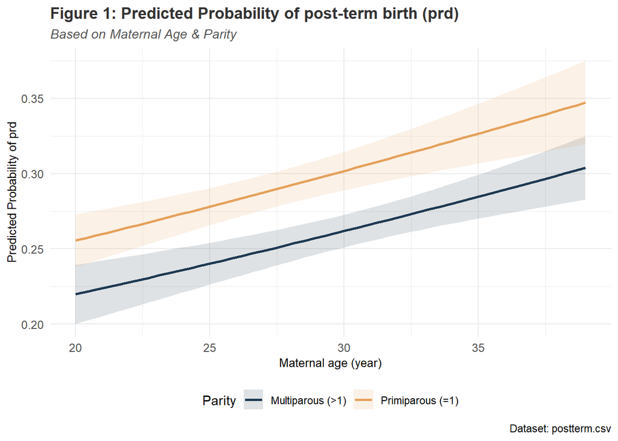

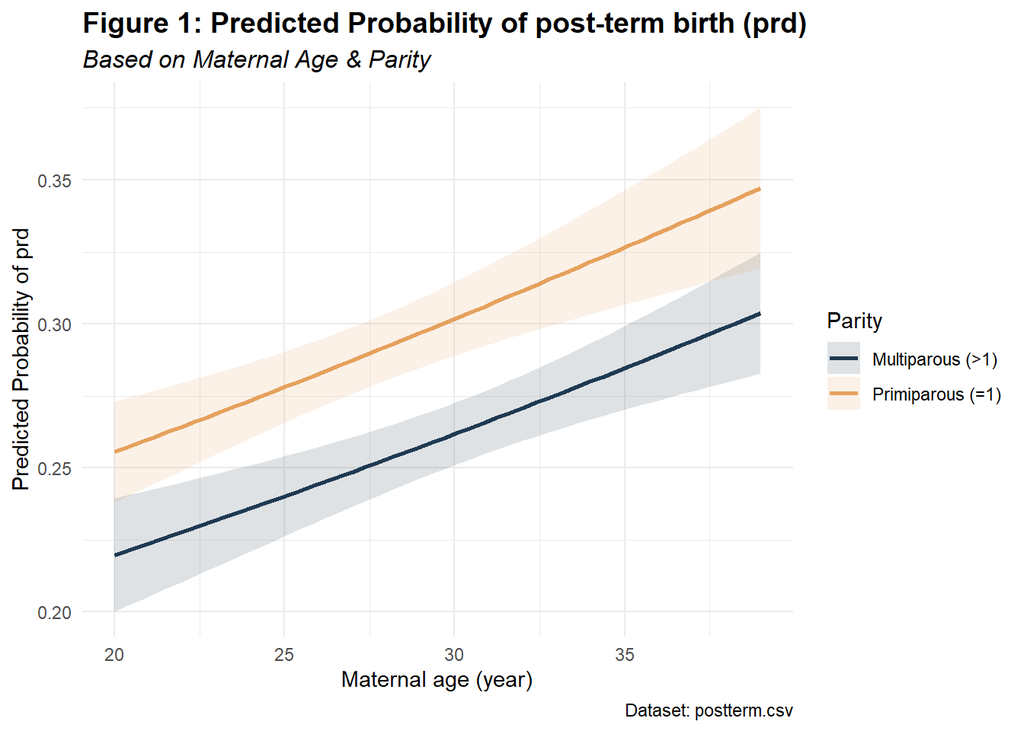

**INTERPRETATION**

The slope estimate doesn’t changed when comparing the crude model with the adjusted one; see $\text{Table 2,}$ $\text{OR}_{age}$. This indicates that $\text{parity}$ isn’t a confounder for the association between post-term birth ($\text{pdr}$) and maternal age ($\text{age}$). This effect is called *independent main effects; the parity groups and the maternal age have their own independent and statistically significant risk factors for the association to post-term births*.

#### 3.1.2. EFFECT MODIFICATION

To evaluate if parity status have an effect modification on the association, an interactive term is included in the model:

**The model**
$$\text{ptd} =
\beta_\text{0} + \beta_\text{1} \cdot \text{age} + \beta_\text{2} \cdot
\text{parity} + \beta_\text{3} \cdot \text{parity} \cdot
\text{age}$$

**Table 3: Comparing the simple & mult1iple model for the association between post-term birth (ref. = No) & maternal age, with a interactive term between age and parity**

|  | *Dependent variable:* |  |
| --- | --- | --- |
|  | Post-term birth (ptd) |  |
|  | Simple model | Mult1iple model |
|  | (1) | (2) |
| Maternal age (year) | 1.02*** | 1.03*** |
|  | (1.01, 1.03) | (1.01, 1.04) |
| Parity status (ref. = primiparous) |  | 1.39 |
|  |  | (0.79, 2.44) |
| Interaction (age:parity) |  | 1.00 |
|  |  | (0.98, 1.01) |
| Intercept | 0.24*** | 0.17*** |
|  | (0.18, 0.31) | (0.11, 0.25) |
| Observations | 12,311 | 12,311 |
| *Note:* | p<0.05; p<0.01; p<0.001 |  |

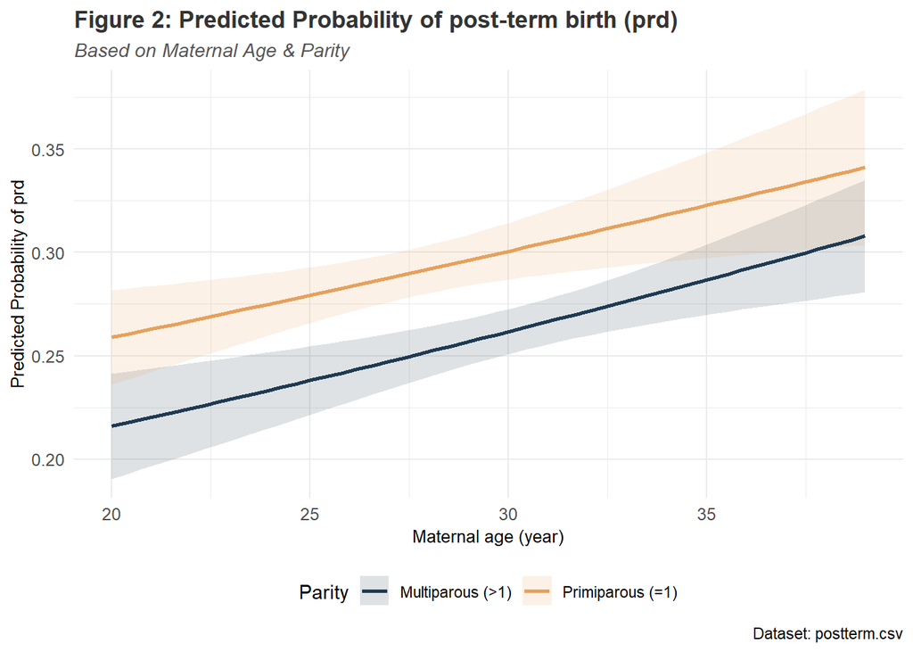

```
##
## Table 3: Comparing the simple & mult1iple model for the association between post-term birth (ref. = No) & maternal age, with a interactive term between age and parity
## =================================================================
##                                         Dependent variable:
##                                    ------------------------------
##                                        Post-term birth (ptd)
##                                     Simple model  Mult1iple model
##                                         (1)             (2)
## -----------------------------------------------------------------
## Maternal age (year)                   1.02***         1.03***
##                                     (1.01, 1.03)   (1.01, 1.04)
##
## Parity status (ref. = primiparous)                     1.39
##                                                    (0.79, 2.44)
##
## Interaction (age:parity)                               1.00
##                                                    (0.98, 1.01)
##
## Intercept                             0.24***         0.17***
##                                     (0.18, 0.31)   (0.11, 0.25)
##
## -----------------------------------------------------------------
## Observations                           12,311         12,311
## =================================================================
## Note:                               *p<0.05; **p<0.01; ***p<0.001
```

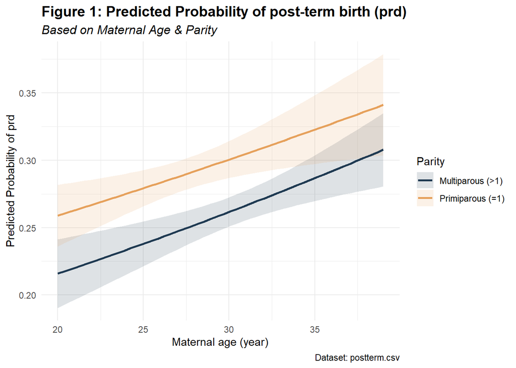

**INTERPRETATION**

Table 3 shows that there is no effect modification between parity status and the association between maternal age and post-term birth. The interaction term is not statistically significant, with an $\text{OR}_{interactive}$, 1 (0.98; 1.01, p 0.643).

#### 3.1.3 LINEAR EFFECT ON LOG(ODDS)-SCALE

Given the absence of effect modification by parity status, the linear effect of maternal age on the log-odds scale was subsequently evaluated. To achieve this, a quadratic term was incorporated into the model using the `I()`-function.

**Table 4: Comparing the simple & quadiple model for the association between post-term birth (ref. = No) & maternal age, with a quadratic term between age and parity**

[output not shown]

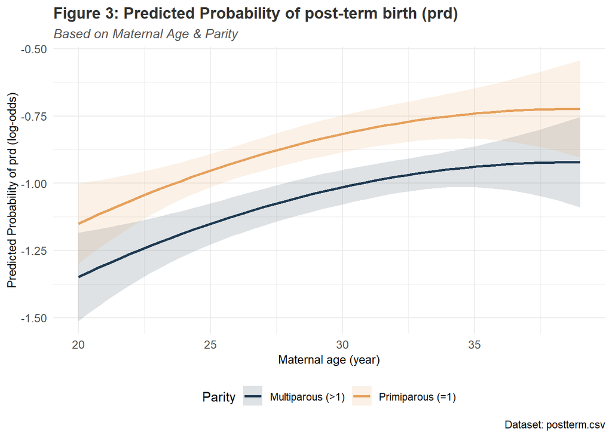

**INTERPRETATION**

**Quadratic term, I(age):** The estimate shows that the quadratic term does not significantly alter the odds, meaning that a curved line does not improve the model compared to a linear one; (95% CI: 1; 1, p 0.173).

In addition, while *Figure 3 displays a visual curvature* on the log-odds scale, this occurs because R rounds the table estimate to two decimal places while the figure captures the underlying microscopic effect. However, as this curve is not statistically significant, it represents statistical noise rather than a real non-linear effect.

#### 3.1.3. The effect of maternal age ($\text{age}$) for each of the two parity groups ($\text{parity}$).

```
##     Hypothesis test   OR CI_low CI_high       p
## 1 Primiparaous (=1) 1.03   1.01    1.04 < 0.001
## 2 Multiparaous (>1) 1.02   1.01    1.04  < 0.05
```

**INTERPRETATION**

The small difference between the two parity groups is a reflection of the non-significant effect modification shown in *table 3*.

#### 3.1.4. The specific effect for two women

Unlike in *Section 2.1.1*, the intercept is included here because we are calculating the specific odds for two individual profiles.

1. A 35-year-old multiparous woman.
2. A 30-year-old primiparous woman.

```
##   Hypothesis test   OR CI_low CI_high       p
## 1        Person A 0.48   0.42    0.54 < 0.001
## 2        Person B 0.31   0.17    0.55 < 0.001
## 3           Diff. 1.54   0.92    2.59   0.102
```

**INTERPRETATION**

### 3.2. ASSOCIATION BETWEEN STATUS FOR POST-TERM BIRTH ($\text{ptd}$) & CATAGORIZED MATERNAL AGE ($\text{age}_{group}$) ADJUSTED FOR PARITY ($\text{parity}$)

To choose the right categorization a histogram is made to get a overview of the distruption

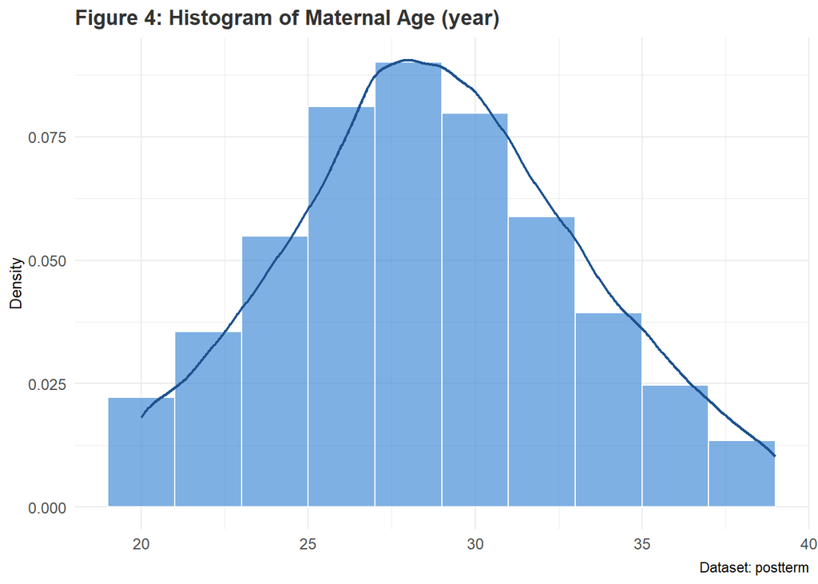

Figure 4 shows, that Maternal Age is normally distributed with the highest number of observation close to 30 years of age. To make sure that enough individuals are spread out into each category, three categories are made; <25, 25-30, and >30.

**The model**
$$\text{ptd} =
\beta_\text{0} + \beta_\text{1} \cdot \text{age}_{group} +
\beta_\text{2} \cdot \text{parity}$$

**Table 5: Multiple model for the association between post-term birth (ref. = No) & maternal age (category), adjusted for parity**

|  | *Dependent variable:* |
| --- | --- |
|  | Post-term birth (ptd) |
| Maternal age (ref. = <=25) | 0.86** |
|  | (0.78, 0.96) |
| Maternal age (ref. = >30) | 1.13** |
|  | (1.03, 1.24) |
| Parity status (ref. = primiparous) | 1.21*** |
|  | (1.12, 1.32) |
| Intercept | 0.34*** |
|  | (0.32, 0.37) |
| Observations | 12,311 |
| *Note:* | p<0.05; p<0.01; p<0.001 |

**INTERPRETATION**

**Reference group:** A multiparous mother with a maternal age between 25–30 years.

**Parity status (ref. = primiparous):** Same as above..

#### 3.2.1. EFFECT MODIFICATION

To evaluate if parity status have an effect modification on the association, an interactive term is included in the model:

**The model**
$$\text{ptd} =
\beta_\text{0} + \beta_\text{1} \cdot \text{age}_{group} +
\beta_\text{2} \cdot \text{parity} + \beta_\text{3} \cdot \text{parity}
\cdot \text{age}_{group}$$

**Table 5: Comparing the two multiple model for the association between post-term birth (ref. = No) & maternal age (category), adjusted for parity**

|  | *Dependent variable:* |  |
| --- | --- | --- |
|  | Post-term birth (ptd) |  |
|  | No Interaction | Interaction |
|  | (1) | (2) |
| Maternal age (ref. = <=25) | 0.86** | 0.77** |
|  | (0.78, 0.96) | (0.64, 0.92) |
| Maternal age (ref. = >30) | 1.13** | 1.13* |
|  | (1.03, 1.24) | (1.00, 1.27) |
| Parity status (ref. = primiparous) | 1.21*** | 1.18** |
|  | (1.12, 1.32) | (1.04, 1.33) |
| Interaction (<=25:primiparous) |  | 1.19 |
|  |  | (0.95, 1.49) |
| Interaction (>30:primiparous) |  | 0.99 |
|  |  | (0.82, 1.19) |
| Intercept | 0.34*** | 0.35*** |
|  | (0.32, 0.37) | (0.32, 0.38) |
| Observations | 12,311 | 12,311 |
| *Note:* | p<0.05; p<0.01; p<0.001 |  |

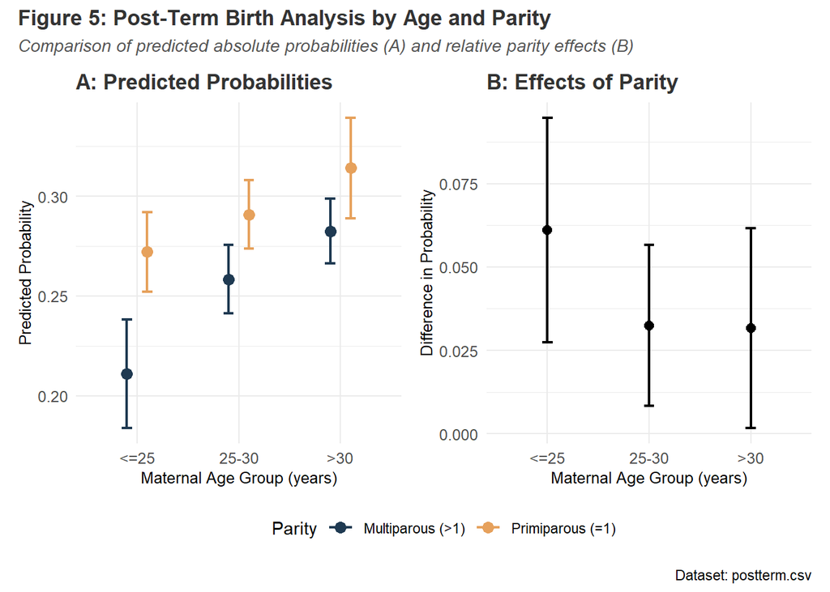

**INTERPRETATION**

Consequently, it can be concluded that *there is no evidence of effect modification between parity and maternal age categories in relation to the risk of post-term birth*.

#### 3.2.2. GLOBAL TEST

When a model includes categorized variables, like $\text{age}_{group}$, separate significances for each category are calculated. By due so allows for increased risk of random chance, also called Type I error. To counderact this, a `global test` is made. This test allows us to test all interaction terms together and thereby test for no absolut interaction.

The `hypotheses`-function is used with inclusion of `joint_test = “chisq”`.

“When a model includes categorized variables, such as $\text{age}_{group}$, separate significance tests are performed for each individual category. Doing so increases the cumulative risk of finding a significant result by random chance, a phenomenon known as a Type I error. To counteract this issue, a `global test` is conducted. This approach evaluates all interaction terms simultaneously, thereby testing for an overall interaction effect.

Methodologically, this was achieved using the `hypotheses()`-function specifying a $\chi^2\text{-test}$ (`joint_test = "chisq"`).”

Table 7: Global test

| Statistic | df | p |
| --- | --- | --- |
| 2.67 | 2 | 0.264 |

**INTERPRETATION**

The global test confirms that there is no statistically significant overall effect modification between maternal age groups and parity on the risk of post-term birth

#### 3.2.3. THE SPECIFIC EFFECT

Unlike in *Section 2.1.1*, the intercept is included here because we are calculating the specific odds for two individual profiles.

1. A 20-year-old multiparous woman.
2. A 35-year-old multiparous woman.

Table 8: Specific effect

| Identity | Probability | CI_low | CI_high | p |
| --- | --- | --- | --- | --- |
| Person A | 0.21 | 0.18 | 0.24 | < 0.001 |
| Person B | 0.28 | 0.27 | 0.30 | < 0.001 |

**INTERPRETATION**

Based on the model, the estimated probabilities of experiencing a post-term birth for the two specific maternal profiles are as follows:

- **20-year-old multiparous woman (Person A):** The predicted probability of a post-term birth is 0.21 (95% CI: 0.18–0.24, p < 0.001), meaning this profile carries a 21% absolute risk.
- **35-year-old multiparous woman (Person B):** The predicted probability increases significantly to 0.28 (95% CI: 0.27–0.30, p < 0.001), corresponding to an absolute risk of 28%.

Consistent with the overall linear trend observed prior to categorization, older maternal age groups continue to exhibit a higher baseline probability of post-term birth among multiparous women.